# Chapter 5 and 6

DJM

25 February 2020

# Exam admonitions

0. You must compile the `.Rmd` to `.html`
1. No code in the `html`.
2. If you put plots or tables in, you must talk about them.

> Rule of thumb: if you don’t have anything good to say about a number, don’t give the number (or plot) at all.
3. **MOST IMPORTANT** you must explain your results. Simply providing them is not likely to get you credit.
4. Look over the model solutions for the last assignments.

# Project progress report

# Simulation

# Why Simulation?

- Up until now, when we do linear models, we used $t$-statistics, $p$-values, CIs
- These things are based on the sampling distribution of the estimators ($\hat{\beta}$) if the model is true and we don’t do any model selection.
- What if we do model selection, use Kernels, think the model is wrong?
- None of those formulas work. And analogous formulas can be **impossible** (or painfully annoying) to derive.

# Some simulation basics

```r
set.seed(2018-02-20)
sample(1:10, replace=TRUE, prob=1:10/10)
```

```
##  [1]  6  8 10  9  7  6  3  9 10  8
```

```r
sample(letters[1:10], replace=TRUE, prob=1:10/10)
```

```
##  [1] "i" "i" "a" "h" "e" "e" "h" "f" "d" "j"
```

```r
sample(letters[1:10], replace=TRUE)
```

```
##  [1] "e" "h" "h" "g" "f" "d" "d" "d" "e" "b"
```

```r
sample(letters[1:10])
```

```
##  [1] "g" "h" "b" "c" "i" "d" "f" "j" "e" "a"
```

# Resampling data

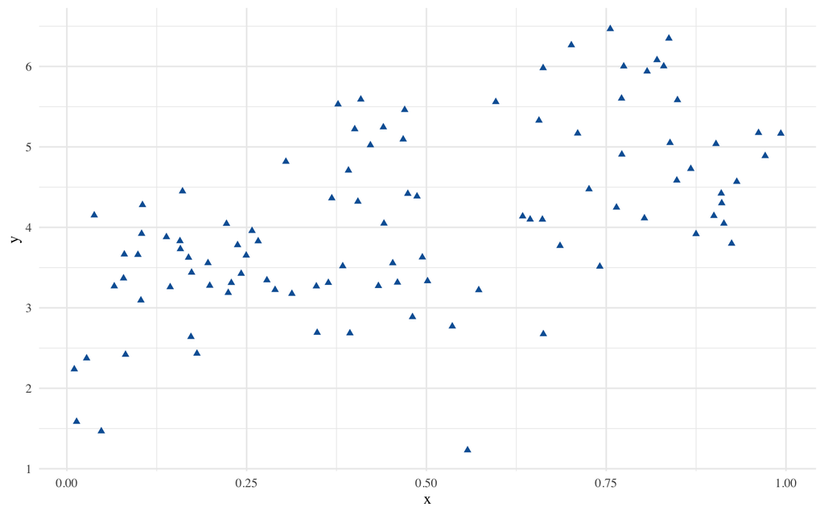

```r
set.seed(2018-02-20)
n = 100; x = runif(n)
df = data.frame(x=x, y=3+2*x+rnorm(n))
ggplot(df, aes(x,y)) + geom_point(color=blue,shape=17)
```

# A sample (with replacement), and a new draw from the same distribution

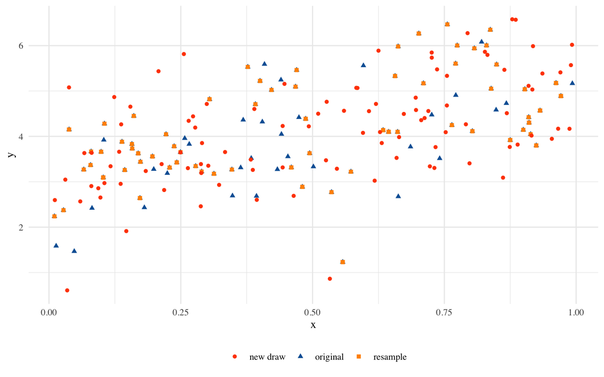

```r
resample <- function(df) {
  stopifnot(is.data.frame(df) | is.matrix(df))
  df[sample(1:nrow(df), replace = TRUE),]
}
df2 = resample(df)
xn = runif(n)
df3 = data.frame(x=xn, y=3+2*xn+rnorm(n))
df = rbind(df,df2,df3)
df$grp = rep(c('original','resample','new draw'), each=n)
p <- ggplot(df, aes(x,y,color=grp)) + geom_point(aes(shape=grp)) +
  scale_color_manual(values=c(red,blue,orange)) +
  theme(legend.title = element_blank(),legend.position = 'bottom')
p
```

# Add some lines

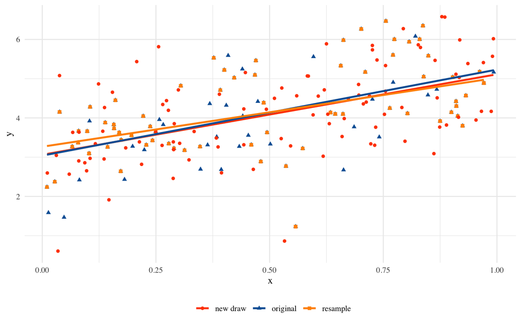

```r
p + geom_smooth(method='lm', se = FALSE)
```

# Using simulations to check modeling assumptions

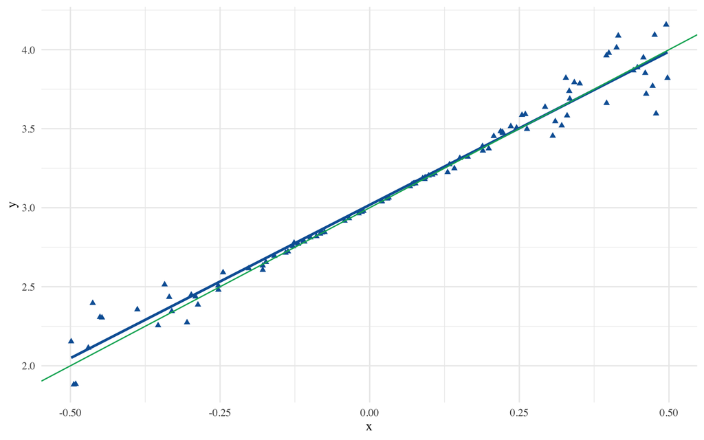

```r
x = runif(n) - 0.5; y = 3+2*x + rnorm(n)*x^2
dfHetero = data.frame(x=x, y=y)
ggplot(dfHetero, aes(x,y)) + geom_point(color=blue,shape=17) +
  geom_smooth(method='lm', se=FALSE,color=blue) +
  geom_abline(intercept = 3, slope=2, color=green)
```

# If the noise is homoskedastic…

- The red and blue points should have the same distribution

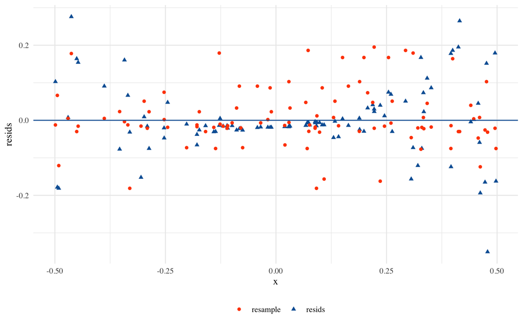

```r
heteromod = lm(y~x,data=dfHetero)
dfHetero$resids = residuals(heteromod)
dfHetero$resample = sample(residuals(heteromod), replace = TRUE)
dfHetero %>% gather(key='type', value='resids',-c(y,x)) %>%
  ggplot(aes(x,resids,color=type,shape=type)) + geom_point() +
  scale_color_manual(values=c(red,blue)) +
  theme(legend.title = element_blank(),legend.position = 'bottom') +
  geom_hline(yintercept=0, color=blue)
```

# That one was easy

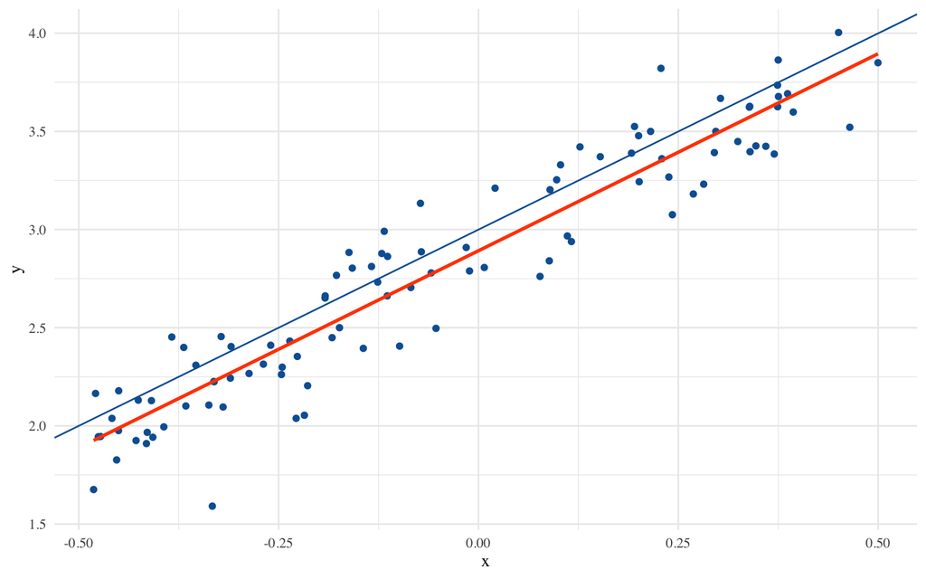

```r
x = runif(n)-0.5
y = 3+2*x + c(arima.sim(list(ar=.8), n, rand.gen = function(n) 0.1* rt(n, df=5)))
dfTS = data.frame(x=x, y=y)
ggplot(dfTS, aes(x,y)) + geom_point(color=blue) +
  geom_smooth(method='lm',se=FALSE, color=red) +
  geom_abline(intercept = 3, slope = 2, color=blue)
```

# If the noise is homoskedastic…

- The red and blue points should have the same distribution

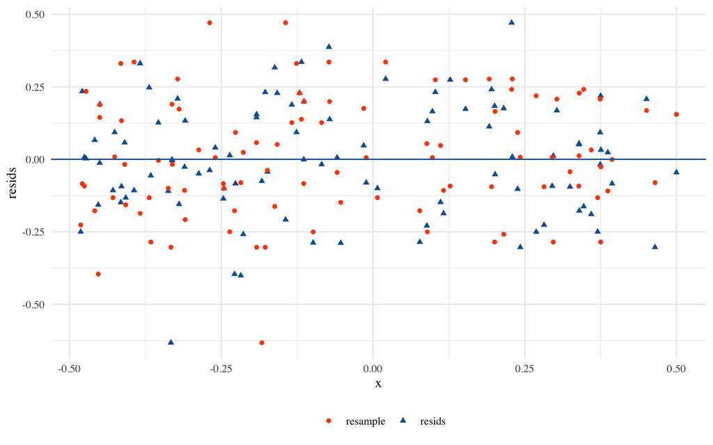

```r
tsMod = lm(y~x, data=dfTS)
dfTS$resids = residuals(tsMod)
dfTS$resample = sample(residuals(tsMod), replace = TRUE)
dfTS %>% gather(key='type', value='resids',-c(y,x)) %>%
  ggplot(aes(x,resids,color=type,shape=type)) + geom_point() +
  scale_color_manual(values=c(red,blue)) +
  theme(legend.title = element_blank(),legend.position = 'bottom') +
  geom_hline(yintercept=0, color=blue)
```

# But…

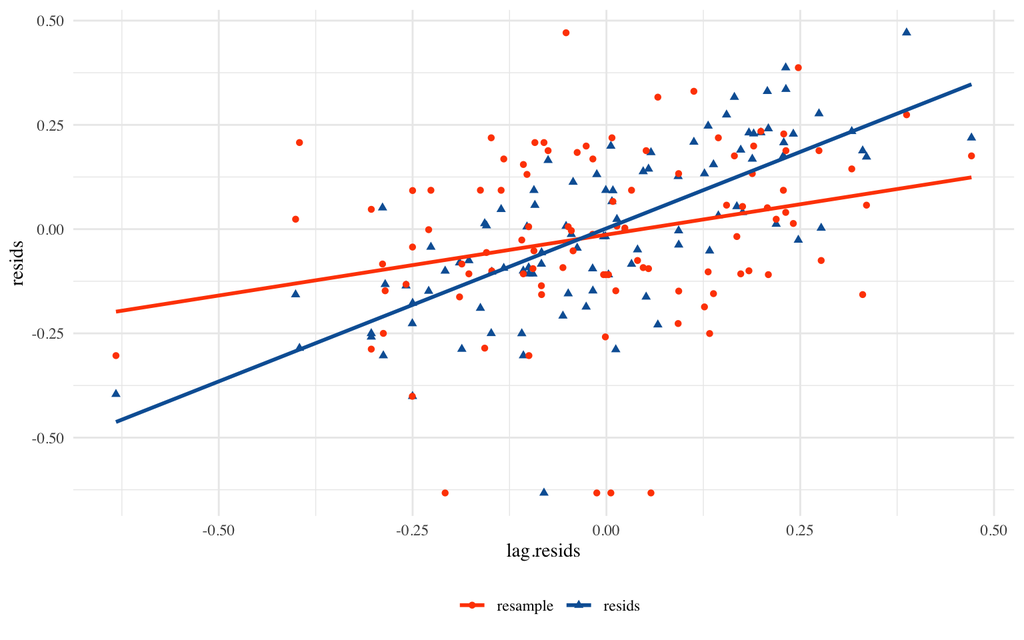

```r
lag.resids = with(dfTS, data.frame(lag.resids = resids[-n], resids = resids[-1]))
lag.resids$resample = sample(lag.resids$resids, replace = TRUE)
lag.resids %>% gather(key='type', value='resids',-lag.resids) %>%
  ggplot(aes(lag.resids,resids,color=type,shape=type)) + geom_point() +
  scale_color_manual(values=c(red,blue)) +
  theme(legend.title = element_blank(),legend.position = 'bottom') +
  geom_smooth(method='lm',se=FALSE)
```

# Another useful command

```r
sample.int(10)
```

```
##  [1]  1 10  5  2  9  4  6  8  3  7
```

# What’s the deal with this Bootstrap?

[figure not shown]

```r
knitr::include_graphics("gfx/bootstraps.jpg")
```

# What’s the deal with this Bootstrap?

- Suppose I want to estimate something and get a CI.
- But I don’t know how to calculate the CI (or maybe I do, but it’s hard)
- Then what?

# Example 1

- Let $X_i\sim \chi_4^2$.
- I know if I estimate the mean with $\bar{X}$, then by the CLT (if $n$ is big),
  $$\frac{\sqrt{n}(\bar{X}-\mathbb{E}\left[ X \right])}{s} \approx N(0, 1).$$
- This gives me a 95% confidence interval like
  $$\bar{X} \pm 2*s/\sqrt{n}$$
- But I don’t want to estimate the mean, I want to estimate the median.

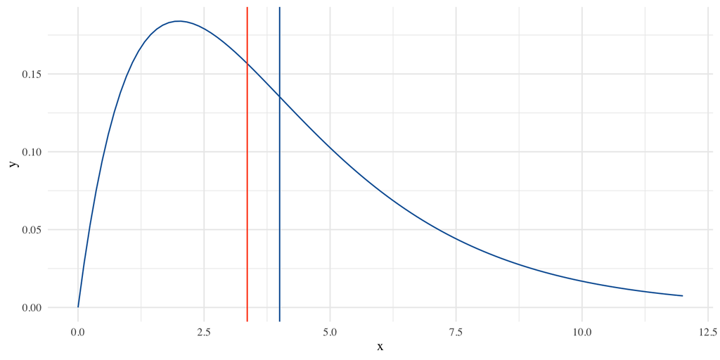

```r
ggplot(data.frame(x=c(0,12)), aes(x)) +
  stat_function(fun=function(x) dchisq(x, df=4), color=blue) +
  geom_vline(xintercept = 4, color=blue) + # mean
  geom_vline(xintercept = qchisq(.5,4), color=red) # median
```

# Now what

```r
set.seed(2018-02-20)
x = rchisq(n, 4)
(med = median(x))
```

```
## [1] 2.570231
```

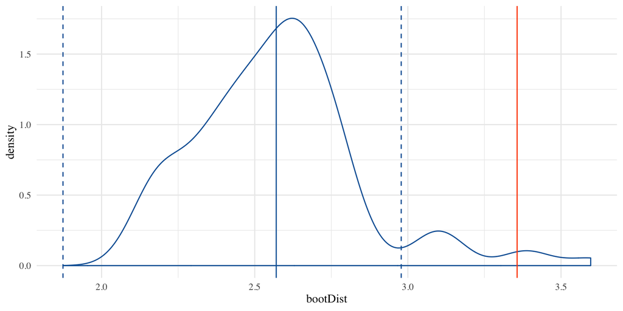

```r
B = 100
alpha = 0.05
bootMed <- function(x) median(sample(x, replace=TRUE))
bootDist = replicate(B, bootMed(x))
bootCI = 2* med - quantile(bootDist, probs = c(1-alpha/2, alpha/2))
ggplot(data.frame(bootDist), aes(bootDist)) + geom_density(color=blue) +
  geom_vline(xintercept = bootCI, col=blue, linetype=2) +
  geom_vline(xintercept = med, col=blue) +
  geom_vline(xintercept = qchisq(.5, 4), col=red) # truth
```

# An alternative

- In that bootstrap, I didn’t use any information about the data-generating process.
- What if I told you that the data came from a $\chi^2$, but I didn’t tell you the degrees of freedom?
- You could try a “parametric” bootstrap:

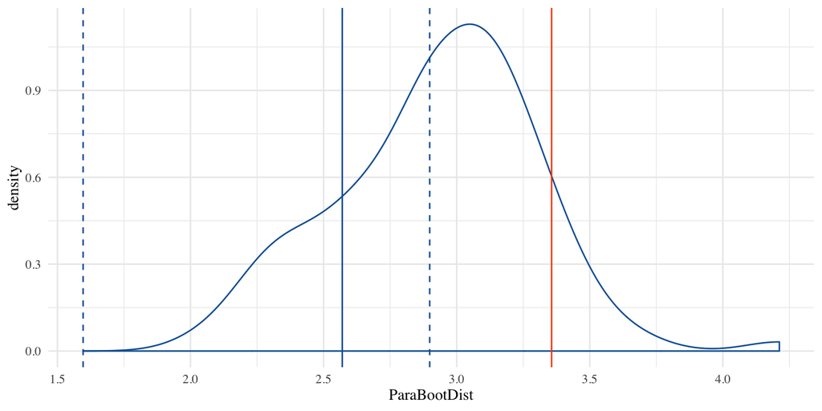

```r
xbar = mean(x)
s = sd(x)
ParaBootSamp <- function(B, xbar, s){
  means = rnorm(B, mean=xbar, sd=s/sqrt(n))
  meds = qchisq(.5, means)
  return(meds)
}
ParaBootDist = ParaBootSamp(B, xbar, s)
ParaBootCI = 2* med - quantile(ParaBootDist, probs = c(1-alpha/2, alpha/2))
ggplot(data.frame(bootDist), aes(ParaBootDist)) + geom_density(color=blue) +
  geom_vline(xintercept = ParaBootCI, col=blue, linetype=2) +
  geom_vline(xintercept = med, col=blue) +
  geom_vline(xintercept = qchisq(.5, 4), col=red) # truth
```

# In truth

- Let’s compare these intervals
- The nonparametric bootstrap (first one) had a width of

```r
bootCI[2] - bootCI[1]
```

```
##    2.5%
## 1.10425
```

- The parametric bootstrap (second one) had a width of

```r
ParaBootCI[2] - ParaBootCI[1]
```

```
##     2.5%
## 1.302101
```

- Using theory, we could find the exact CI. In this case, it has a width of 1.76.

# Bootstrap diagram

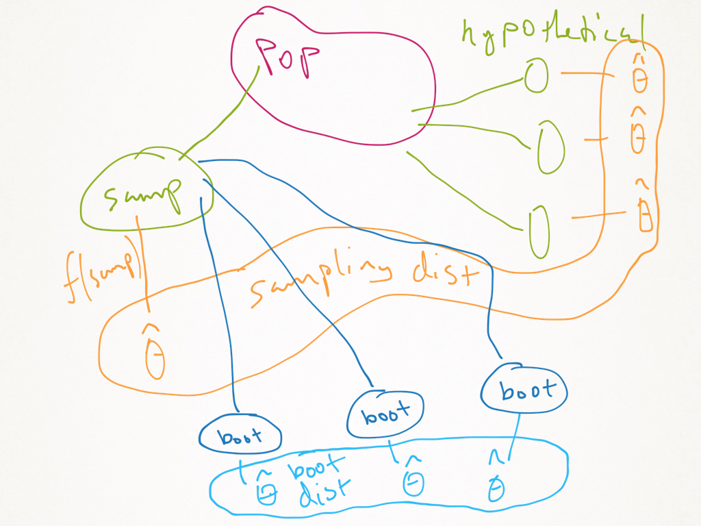

# Bootstrap intuition

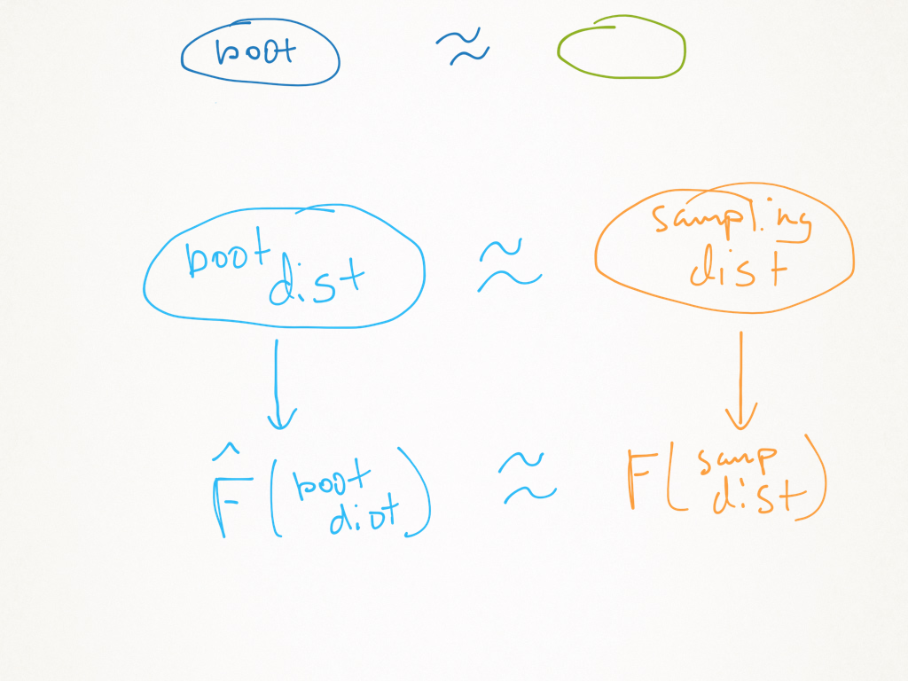

# Bootstrap error sources

(From the bottom up on the last slide)

1. Simulation error: using only $B$ samples to estimate $F$ with $\hat{F}$.
2. Statistical error: our data depended on a sample from the population. We don’t have the whole population so we make an error by using a sample (Note: this part is what **always** happens with data, and what the science of statistics analyzes.)
3. Specification error: If we use the model based bootstrap, and our model is wrong, then we think we are badly overconfident in our assessment of error.

# Recap

- There are essentially 2 types of bootstrap
  1. Parametric
  2. Nonparametric
- If you **really** believe your model, use the first
- If not, use the second
- Both are valid

# Example 2 (using code from Book on new data)

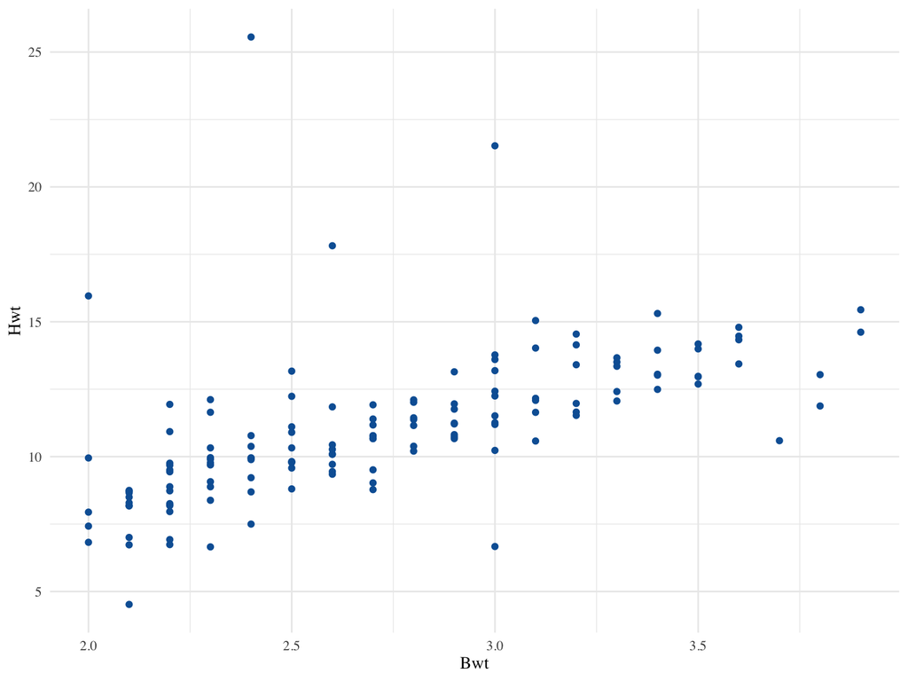

```r
library(MASS)
ggplot(fatcats, aes(Bwt, Hwt)) + geom_point(color=blue)
```

# A model

```r
## Running the model on the original data
cats.lm = lm(Hwt ~ 0+Bwt,data=fatcats)
summary(cats.lm)
```

```
##
## Call:
## lm(formula = Hwt ~ 0 + Bwt, data = fatcats)
##
## Residuals:
##     Min      1Q  Median      3Q     Max
## -5.4366 -0.9116 -0.1709  0.5164 15.8740
##
## Coefficients:
##     Estimate Std. Error t value Pr(>|t|)
## Bwt  4.03491    0.06664   60.55   <2e-16 ***
## ---
## Signif. codes:  0 '***' 0.001 '**' 0.01 '*' 0.05 '.' 0.1 ' ' 1
##
## Residual standard error: 2.212 on 143 degrees of freedom
## Multiple R-squared:  0.9625, Adjusted R-squared:  0.9622
## F-statistic:  3666 on 1 and 143 DF,  p-value: < 2.2e-16
```

```r
confint(cats.lm)
```

```
##        2.5 %  97.5 %
## Bwt 3.903179 4.16664
```

# I think that that CI is wrong…

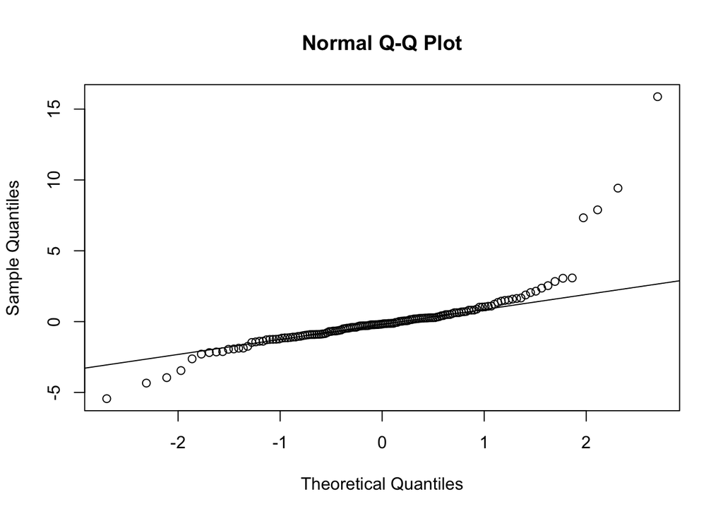

```r
qqnorm(residuals(cats.lm))
qqline(residuals(cats.lm))
```

# Functions to borrow

```r
resample <- function(x) {
    sample(x, replace = TRUE)
}
resample.data.frame <- function(data) {
    sample.rows <- resample(1:nrow(data))
    return(data[sample.rows, ])
}
rboot <- function(statistic, simulator, B) {
    tboots <- replicate(B, statistic(simulator()))
    if (is.null(dim(tboots))) {
        tboots <- array(tboots, dim = c(1, B))
    }
    return(tboots)
}
bootstrap <- function(tboots, summarizer, ...) {
    summaries <- apply(tboots, 1, summarizer, ...)
    return(t(summaries))
}
equitails <- function(x, alpha) {
    lower <- quantile(x, alpha/2)
    upper <- quantile(x, 1 - alpha/2)
    return(c(lower, upper))
}
bootstrap.ci <- function(statistic = NULL, simulator = NULL, tboots = NULL,
    B = if (!is.null(tboots)) {
        ncol(tboots)
    }, t.hat, level) {
    if (is.null(tboots)) {
        stopifnot(!is.null(statistic))
        stopifnot(!is.null(simulator))
        stopifnot(!is.null(B))
        tboots <- rboot(statistic, simulator, B)
    }
    alpha <- 1 - level
    intervals <- bootstrap(tboots, summarizer = equitails, alpha = alpha)
    upper <- t.hat + (t.hat - intervals[, 1])
    lower <- t.hat + (t.hat - intervals[, 2])
    CIs <- cbind(lower = lower, upper = upper)
    return(CIs)
}
```

# Model

```r
## Simulator
resamp.resids.cats <- function(){
  resids = residuals(cats.lm)
  newResids = sample(resids, replace=TRUE)
    # resample the residuals from the original model
  newCats = data.frame(Bwt = fatcats$Bwt,
    Hwt=fitted(cats.lm) + newResids) # create a new dataframe
                                     # with the original x's but new y's
  return(newCats)
}
## Estimator
fitCats <- function(newCats) coef(lm(Hwt~0+Bwt, data=newCats)) # get the coef from OLS
fitCats(fatcats) # test the above on original data, should give same coef
```

```
##      Bwt
## 4.034909
```

# Model-based bootstrap

```r
cisPara = bootstrap.ci(statistic = fitCats,
                       simulator = resamp.resids.cats,
                       B = 1000, t.hat = fitCats(fatcats),
                       level = 0.95)
```

# Nonparametric bootstrap

```r
resamp.cats <- function() resample.data.frame(fatcats)
cisNonPara = bootstrap.ci(statistic = fitCats,
                          simulator = resamp.cats,
                          B = 1000, t.hat = fitCats(fatcats),
                          level = 0.95)
  # use the prev func to
  # bootstrap on resampled data
cisPara
```

```
##        lower    upper
## Bwt 3.868765 4.130831
```

```r
cisNonPara
```

```
##       lower    upper
## Bwt 3.90625 4.159418
```

# Bootstrapping with nonparametric regression

- This is a bit harder
- The reason is that we use CV to choose the bandwidth
- So we have to repeat that step in the bootstrapping
- That is:
  1. Input data
  2. Use CV to choose a smoothing parameter
  3. Use the chosen parameter to estimate the smooth function
  4. Resample the data
  5. Using this new data, repeat 2 and 3